# Beer And Breweries

Jon Paugh & Jason Rupp

10/4/2019

# Analysis of brewery and beer data

## The purpose of this RMD is to perform an analysis of the craft beer and brewery data, answering a series of questions as with an audience of executives from a beer company (e.g. CEO and CFO of Budweiser, our client). This beer and brewery data is in fact data about craft breweries and can be found here:

## https://www.kaggle.com/nickhould/craft-cans

#install packages

```r
#install.packages(c("plyr", "tidyverse", "jsonlite", "rvest", "naniar", "stringi",
#                   "gridExtra", "usmap", "maps", "MASS", "ggmap", "class", "caret"))
#install.packages("e1071", dependencies = TRUE)
```

#Load Libraries

```r
library(plyr)
library(tidyverse)
library(jsonlite)
library(rvest)
library(naniar)
library(stringi)
library(gridExtra)
```

```r
library(usmap)
library(maps)
library(MASS)
library(ggmap)
library(class)
library(caret)
library(e1071)
```

# read the data

```r
Beer = read.csv("beers.csv")
Brewery = read.csv("breweries.csv")
```

# initial analysis

```r
str(Beer)
```

```
## 'data.frame':    2410 obs. of  7 variables:
##  $ Name      : Factor w/ 2305 levels "#001 Golden Amber Lager",..: 1638 577 1704 1842 1819 268 1160 758 1093 486 ...
##  $ Beer_ID   : int  1436 2265 2264 2263 2262 2261 2260 2259 2258 2131 ...
##  $ ABV       : num  0.05 0.066 0.071 0.09 0.075 0.077 0.045 0.065 0.055 0.086 ...
##  $ IBU       : int  NA NA NA NA NA NA NA NA NA NA ...
##  $ Brewery_id: int  409 178 178 178 178 178 178 178 178 178 ...
##  $ Style     : Factor w/ 100 levels "","Abbey Single Ale",..: 19 18 16 12 16 80 18 22 18 12 ...
##  $ Ounces    : num  12 12 12 12 12 12 12 12 12 12 ...
```

```r
str(Brewery)
```

```
## 'data.frame':    558 obs. of  4 variables:
##  $ Brew_ID: int  1 2 3 4 5 6 7 8 9 10 ...
##  $ Name   : Factor w/ 551 levels "10 Barrel Brewing Company",..: 355 12 266 319 201 136 227 477 59 491 ...
##  $ City   : Factor w/ 384 levels "Abingdon","Abita Springs",..: 228 200 122 299 300 62 91 48 152 136 ...
##  $ State  : Factor w/ 51 levels " AK"," AL"," AR",..: 24 18 20 5 5 41 6 23 23 23 ...
```

```r
head(Beer)
```

```
##                  Name Beer_ID   ABV IBU Brewery_id
## 1            Pub Beer    1436 0.050  NA        409
## 2         Devil's Cup    2265 0.066  NA        178
## 3 Rise of the Phoenix    2264 0.071  NA        178
## 4            Sinister    2263 0.090  NA        178
## 5       Sex and Candy    2262 0.075  NA        178
## 6        Black Exodus    2261 0.077  NA        178
##                            Style Ounces
## 1            American Pale Lager     12
## 2        American Pale Ale (APA)     12
## 3                   American IPA     12
## 4 American Double / Imperial IPA     12
## 5                   American IPA     12
## 6                  Oatmeal Stout     12
```

```r
head(Brewery)
```

```
##   Brew_ID                      Name          City State
## 1       1        NorthGate Brewing    Minneapolis    MN
## 2       2 Against the Grain Brewery    Louisville    KY
## 3       3  Jack's Abby Craft Lagers    Framingham    MA
## 4       4 Mike Hess Brewing Company     San Diego    CA
## 5       5   Fort Point Beer Company San Francisco    CA
## 6       6     COAST Brewing Company    Charleston    SC
```

# join together the brewery and beer info

```r
dfFull = left_join(Beer, Brewery, by = c("Brewery_id" =  "Brew_ID"))
```

# check fail of join rows

```r
dfFullNoJoin <- dfFull[is.na(dfFull$City),]
#dfFullNoJoin
# every beer has a corresponding brewery
```

# analysis

## 1. How many breweries are present in each state?

## After execution of the code below, the dataframe dfBreweryByState gives the totals by state.

```r
dfBreweryByState <- Brewery %>%
  group_by(State) %>%
  summarize(BreweryCount = n()) %>% rename(state = State)

head(dfBreweryByState %>% arrange(desc(dfBreweryByState$BreweryCount)), n=3)
```

```
## # A tibble: 3 x 2
##   state BreweryCount
##   <fct>        <int>
## 1 " CO"           47
## 2 " CA"           39
## 3 " MI"           32
```

```r
head(dfBreweryByState %>% arrange(dfBreweryByState$BreweryCount), n=4)
```

```
## # A tibble: 4 x 2
##   state BreweryCount
##   <fct>        <int>
## 1 " DC"            1
## 2 " ND"            1
## 3 " SD"            1
## 4 " WV"            1
```

```r
mean(as.numeric(dfBreweryByState$BreweryCount))
```

```
## [1] 10.94118
```

## The following code generates 4 outputs: 1) shows the dataframe dfBreweryByState, 2) shows breweries count by state in a barchart 3) Shows Breweries by state on a state map, 4) Shows Breweries by state, per capita (per million persons).

## Colorado has the most breweries overall, while Vermont has the most breweries per population (usingbased on 2015 state populations)

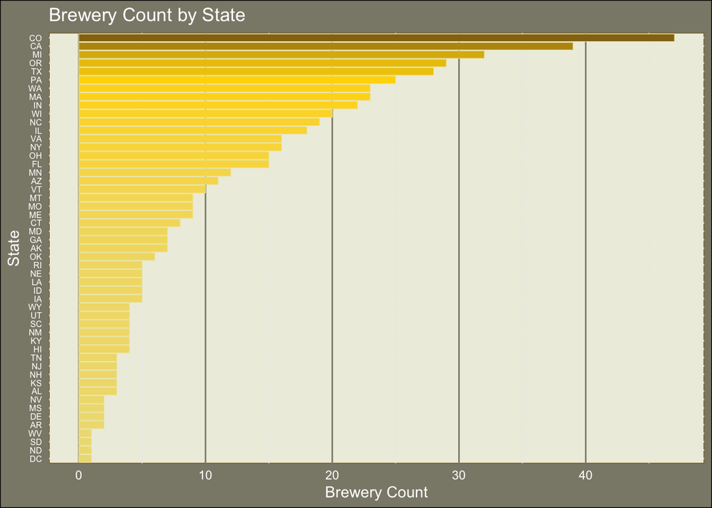

```r
dfBreweryByState = dfBreweryByState %>% mutate(abbr = trimws( as.character(state)))
dfBreweryByState <- dfBreweryByState %>% mutate(BreweryCount = as.double(BreweryCount))

dfBreweryByStateWithStatePop = left_join(statepop, dfBreweryByState, by = "abbr")

dfBreweryByStateWithStatePop <- dfBreweryByStateWithStatePop %>% mutate(BreweryPerMil = (BreweryCount / (pop_2015 /1000000) ))


#Histgram with # of breweries per state
dfBreweryByStateWithStatePop %>%
ggplot(color = "black")+
  geom_bar(mapping=aes(x=reorder(state, BreweryCount), y=BreweryCount, fill= BreweryCount), color='palegoldenrod', stat = 'identity', size = 0.2) +
  coord_flip() +
  ylab("Brewery Count") +
  xlab('State') +
  ggtitle('Brewery Count by State') +
  theme_minimal() +
  theme(axis.text=element_text(color = "white"), axis.text.y = element_text(size=6), legend.position =  "none", plot.background = element_rect("cornsilk4"), panel.background = element_rect(color="darkgoldenrod4", fill='ivory2'), panel.grid.major.y = element_line(color="ivory2"), panel.grid.major.x = element_line("cornsilk4"), axis.title = element_text(color = "white"), plot.title = element_text(color = "white")) +
  scale_fill_gradient2(low = "lightgoldenrod", mid = "gold", high = "goldenrod4", midpoint = 25)
```

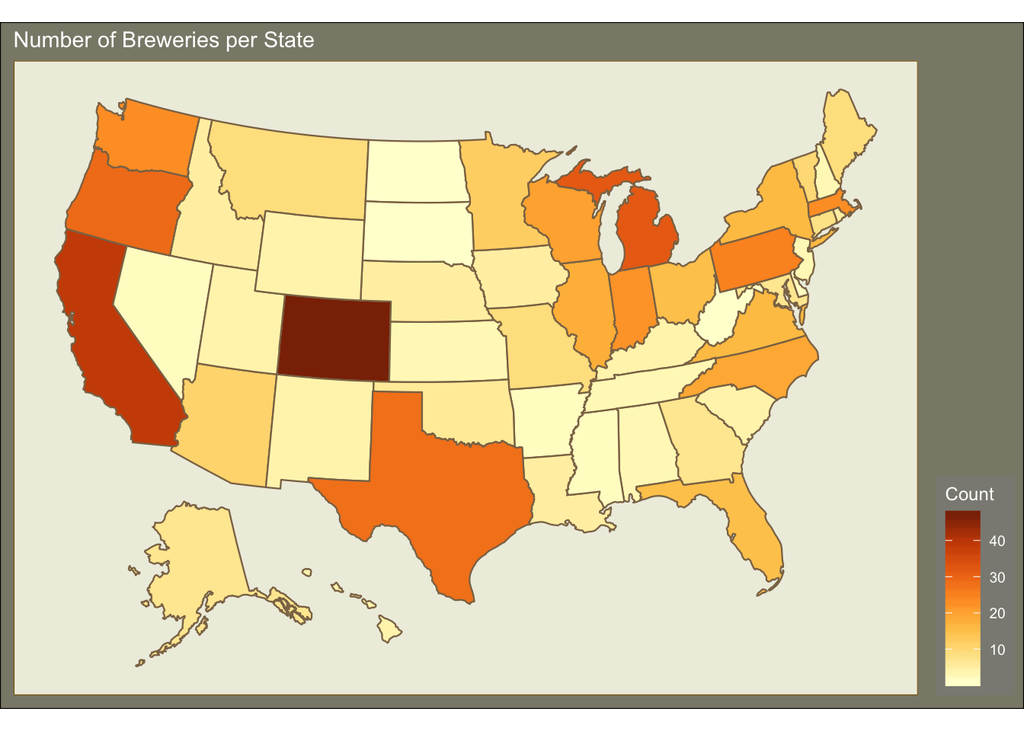

```r
#US heat map by state
plot_usmap(data = dfBreweryByStateWithStatePop, values = "BreweryCount", color = "burlywood4") +
  theme(
    legend.position = "right",
    legend.title = element_text(color = "white"),
    plot.background = element_rect("cornsilk4"),
    panel.background = element_rect(color="darkgoldenrod4", fill='ivory2'),
    plot.title = element_text(color = "white"),
    legend.background = element_rect(fill="ivory4"),
    legend.text = element_text(color = "white")) +
   scale_fill_distiller(type = "div", palette = "YlOrBr", direction = 0, breaks=c(10,20,30,40), name = "Count") +
   labs(title="Number of Breweries per State")
```

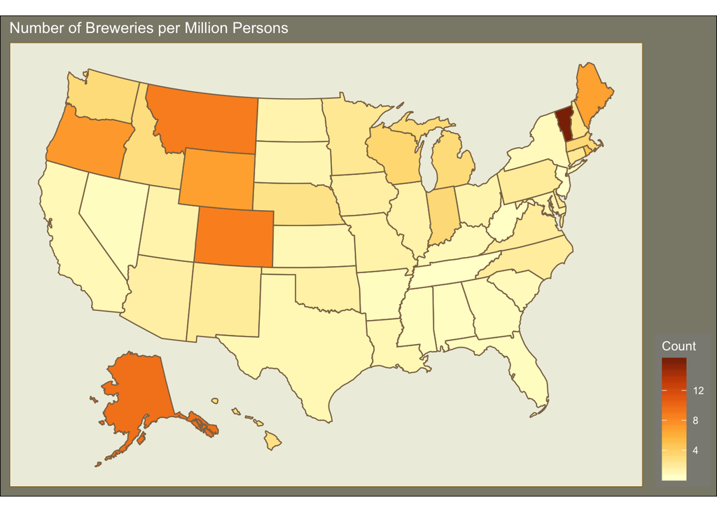

```r
#US heat map per capita
plot_usmap(data = dfBreweryByStateWithStatePop, values = "BreweryPerMil", color = "burlywood4") +
  theme(legend.position = "right", legend.title = element_text(color = "white"), plot.background = element_rect("cornsilk4"), panel.background = element_rect(color="darkgoldenrod4", fill='ivory2'), plot.title = element_text(color = "white"), legend.background = element_rect(fill="ivory4"), legend.text = element_text(color = "white")) +
  scale_fill_distiller(type = "div", palette = "YlOrBr", direction = 0, breaks=c(4,8,12), name = "Count") +
  labs(title="Number of Breweries per Million Persons")
```

## 2. Merge beer data with the breweries data. Print the first 6 observations and the last six observations to check the merged file. (RMD only, this does not need to be included in the presentation or the deck.)

```r
head(dfFull,6)
```

```
##                Name.x Beer_ID   ABV IBU Brewery_id
## 1            Pub Beer    1436 0.050  NA        409
## 2         Devil's Cup    2265 0.066  NA        178
## 3 Rise of the Phoenix    2264 0.071  NA        178
## 4            Sinister    2263 0.090  NA        178
## 5       Sex and Candy    2262 0.075  NA        178
## 6        Black Exodus    2261 0.077  NA        178
##                            Style Ounces                    Name.y City
## 1            American Pale Lager     12 10 Barrel Brewing Company Bend
## 2        American Pale Ale (APA)     12       18th Street Brewery Gary
## 3                   American IPA     12       18th Street Brewery Gary
## 4 American Double / Imperial IPA     12       18th Street Brewery Gary
## 5                   American IPA     12       18th Street Brewery Gary
## 6                  Oatmeal Stout     12       18th Street Brewery Gary
##   State
## 1    OR
## 2    IN
## 3    IN
## 4    IN
## 5    IN
## 6    IN
```

```r
tail(dfFull, 6)
```

```
##                           Name.x Beer_ID   ABV IBU Brewery_id
## 2405 Rocky Mountain Oyster Stout    1035 0.075  NA        425
## 2406                   Belgorado     928 0.067  45        425
## 2407               Rail Yard Ale     807 0.052  NA        425
## 2408             B3K Black Lager     620 0.055  NA        425
## 2409         Silverback Pale Ale     145 0.055  40        425
## 2410        Rail Yard Ale (2009)      84 0.052  NA        425
##                         Style Ounces                  Name.y   City State
## 2405           American Stout     12 Wynkoop Brewing Company Denver    CO
## 2406              Belgian IPA     12 Wynkoop Brewing Company Denver    CO
## 2407 American Amber / Red Ale     12 Wynkoop Brewing Company Denver    CO
## 2408              Schwarzbier     12 Wynkoop Brewing Company Denver    CO
## 2409  American Pale Ale (APA)     12 Wynkoop Brewing Company Denver    CO
## 2410 American Amber / Red Ale     12 Wynkoop Brewing Company Denver    CO
```

## 3. Address the missing values in each column.

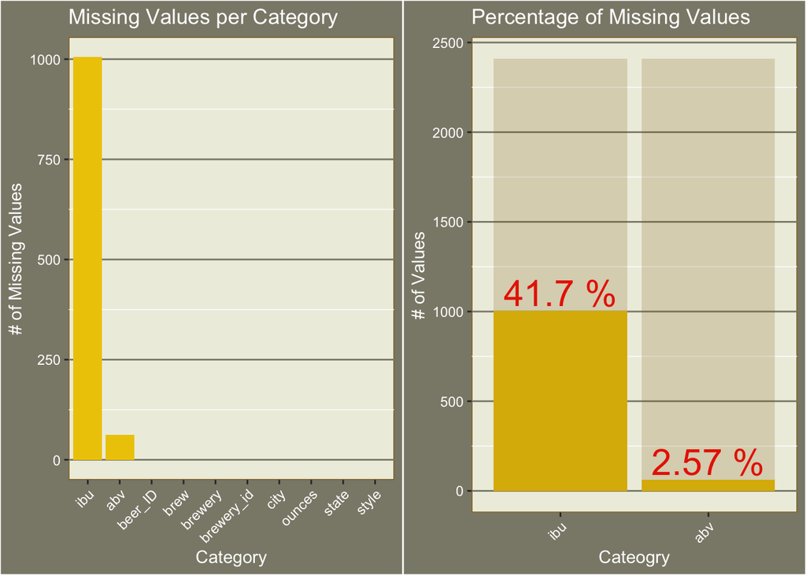

```r
#Here are the NA graphs side by side showing percentage of values missing with central aes applied

names(dfFull) <- c("brew", "beer_ID", "abv", "ibu", "brewery_id", "style", "ounces", "brewery", "city", "state")

#head(dfFull)


#Here we assemble a df out of data to plot missing vals easily to apply themes

notNaCols <- colSums(!is.na(dfFull), na.rm = TRUE) %>% tibble::enframe(name = NULL)

#notNaCols

isNaCols <- colSums(is.na(dfFull), na.rm = FALSE)%>% tibble::enframe(name = NULL)

#isNaCols

dfFull_vt <- cbind(names(dfFull),notNaCols) #


dfFull_vt <- cbind(dfFull_vt, isNaCols)

names(dfFull_vt) <- c("column", "notNA", "isNA")

#head(dfFull_vt)



# Store the raw data rather than truncate, can always truncate later/after

#dfFull_vt <- dfFull_vt %>% mutate(percentNA = mapply(function(x,y) round(y/(x+y),4)*100,dfFull_vt$notNA, dfFull_vt$isNA)) ----> This will calc and round (truncate) percentage missing, chose raw data col, trunc after

dfFull_vt <- dfFull_vt %>% mutate(total = rowSums(dfFull_vt[,2:3]))

dfFull_vt <- dfFull_vt %>% mutate(percentNA = mapply(function(x,y) y/(x+y),dfFull_vt$notNA, dfFull_vt$isNA))

#dfFull_vt


#NA Plot by column with number of missing values

naPlot1 <- dfFull_vt %>%
ggplot(aes(x=reorder(column, -isNA), y = isNA)) +
  geom_histogram(stat = "identity", fill ="gold2") +
  labs(x="Category", y="# of Missing Values", title = "Missing Values per Category") +
  #theme_minimal() +
  theme(axis.text=element_text(color = "white"),
        axis.text.x = element_text(angle=45, hjust = 1),
        legend.position =  "none",
        plot.background = element_rect("cornsilk4"),
        panel.background = element_rect(color="darkgoldenrod4", fill='ivory2'),
        panel.grid.major.y = element_line(color="cornsilk4"),
        panel.grid.major.x = element_blank(),#element_line("ivory2"),
        axis.title = element_text(color = "white"),
        plot.title = element_text(color = "white"),
        panel.grid.minor.x = element_line(color="white"))
#naPlot1

#Shows the two columns with missing vals and the percentage missing

naPlot2 <- dfFull_vt[c(3:4),] %>%
ggplot(aes(x=reorder(column, -isNA), y = isNA)) +
  geom_histogram(stat = "identity", fill = 'gold2') +
  geom_text(data=dfFull_vt[c(3:4),], label=paste(round((dfFull_vt[c(3:4),]$percentNA)*100, 2), "%"),
    y = (dfFull_vt[c(3:4),]$isNA)+100, size = 8, color="red") +
  geom_histogram(data=dfFull_vt[3:4,], mapping = aes(x=column, y = total),
    stat = "identity", alpha = 1/5, fill="darkgoldenrod4") +
  labs(x="Cateogry", y="# of Values", title = "Percentage of Missing Values") +
  #theme_minimal() +
  theme(axis.text=element_text(color = "white"),
        axis.text.x = element_text(angle=45, hjust = 1),
        legend.position =  "none",
        plot.background = element_rect("cornsilk4"),
        panel.background = element_rect(color="darkgoldenrod4", fill='ivory2'),
        panel.grid.major.x = element_blank(),#element_line("ivory2"),
        panel.grid.major.y = element_line(color="cornsilk4"),
        axis.title = element_text(color = "white"),
        plot.title = element_text(color = "white"),
        panel.grid.minor.x = element_line(color="white"))
        #plot.margin = margin(l=-5))

#naPlot2

grid.arrange(naPlot1,naPlot2, nrow=1)
```

```r
# Found Beer style guidelines at this websiite https://www.bjcp.org/stylecenter.php
# They provided a link to an xml doc that has a number of stats about different beer styles
# We parse the required data and create a data frame to attempt to impute missing vals

hp<-read_html("https://raw.githubusercontent.com/meanphil/bjcp-guidelines-2015/master/styleguide.xml")

#hp



#Extracting the major categories 40 total, and the IDs based on the doc for merging

beer_cat <- html_nodes(hp, "category")

beer_catz <- str_extract(as.character(beer_cat), "(<name>)([\\w\\s]+)(</name>)")

beer_catz <- stri_sub(as.character(beer_catz), 7, -8)

beer_catz_id <- str_extract(as.character(beer_cat), "(<category id=)([:graph:]+)(>)")

#beer_catz_id

beer_catz_id <- str_replace_all(str_extract_all(as.character(beer_catz_id), "(\")([:graph:]+)(\")"), "\"", "")

#beer_catz_id


# This is the initial df that contains the cat ids and the beer categories


beer_catz <- data.frame(cat_id = beer_catz_id, category = beer_catz)




# Now we extract the subcategories of each type of beer (136 total)
# Parse the meaningful text with regex
# We didn't make a df until we had the rest of the data for ibus and abvs

beer_subcat <- html_nodes(hp, "subcategory")

beer_subcat <- as.character(beer_subcat)

#beer_subcat

beer_subcatz <- str_extract(beer_subcat, "(<name>)([|\\w|\\d|\\s|[:punct:]]+)(</name>)")

beer_subcatz <- stri_sub(as.character(beer_subcatz), 7, -8)

#beer_subcatz



#Subcategory ID

beer_subcatz_id <- str_extract_all(as.character(beer_subcat), "(<subcategory id=)([:graph:]+)(>)")

#beer_subcatz_id <- str_extract_all(beer_subcatz_id, ("\"[:alnum:]\""))

beer_subcatz_id <- str_replace_all(str_extract_all(as.character(beer_subcatz_id), "(\")([:graph:]+)(\")"), "\"", "")

#beer_subcatz_id





# Starting the Extraction of beer stats


beer_stats <- str_extract(beer_subcat, "(<stats>)((\\s|\\S)+)(</stats>)")

ibu_range <- str_extract(beer_stats, "(<ibu flexible=)((\\s+|\\S+))(</ibu>)")

#ibu_range #Careful printing, sometimes consumed a lot of memory and printed with tons of whitespace for some reason, but the df is good





#Low IBU range

ibu_lrng <-  str_extract(ibu_range, "(<low>)([0-9]+)(</low>)")

ibu_lrng <- str_extract(ibu_lrng, "[0-9]+")

#ibu_lrng





#High IBU range

ibu_hrng <-  str_extract(ibu_range, "(<high>)([0-9]+)(</high>)")

ibu_hrng <- str_extract(ibu_hrng, "[0-9]+")

#ibu_hrng





#Here we merge the extracted IBU ranges with the extracted subcategories
# The remaining df has the ibu ranges lined up with the correct subcat

ibu_rng_df <- data.frame(subcategory_id = beer_subcatz_id, subcategory=beer_subcatz) %>% as_tibble()

ibu_rng_df <- cbind(ibu_rng_df, ibu_lrng, ibu_hrng)

#ibu_rng_df





#Now we repeat what we've done above to extract ABV
#This should be made into a function to save lines of code

abv_range <- str_extract(beer_stats, "(<abv flexible=)((\\s+|\\S+))(</abv>)")

#abv_range




#ABV Low Range

abv_lrng <-  str_extract(abv_range, "(<low>)(([0-9]+)(\\.)([0-9]+)|([0-9]+))(</low>)")

abv_lrng <- str_extract(abv_lrng, "(([0-9]+)(\\.)([0-9]+)|([0-9]+))")

#abv_lrng




#ABV High Range

abv_hrng <-  str_extract(abv_range, "(<high>)(([0-9]+)(\\.)([0-9]+)|([0-9]+))(</high>)")

abv_hrng <- str_extract(abv_hrng, "(([0-9]+)(\\.)([0-9]+)|([0-9]+))")

#abv_hrng




# Join ABV data with Subcategory/IBU data

rng_df <- cbind(ibu_rng_df,abv_lrng, abv_hrng)

#rng_df



#Extracting the Category ID from the Subcategory IDs the line up the subcategories with the categories
#New df name created

rng_df_t <- mutate(rng_df, category_id = substr(as.character(rng_df$subcategory_id), 1, (nchar(as.character(rng_df$subcategory_id))-1)))



#Merging the Subcategory df with the category df to identify the correct category each subcategory belongs to

rng_df_t <- left_join(rng_df_t, beer_catz, by = c("category_id" = "cat_id"))
#rng_df_t




#Reordered for aestethics
rng_df_t <- rng_df_t[c(7,8,1,2,3,4,5,6)]

#head(rng_df_t)



#Computing the mean for each subcategory for IBU/ABV

rng_df_t <- mutate(rng_df_t, ibu_avg = (mapply(function(x, y) ((x+y)/2) , as.numeric(as.character(rng_df_t$ibu_lrng)),as.numeric(as.character(rng_df_t$ibu_hrng)))))

rng_df_t <- mutate(rng_df_t, abv_avg = (mapply(function(x, y) ((x+y)/2) , as.numeric(as.character(rng_df_t$abv_lrng)),as.numeric(as.character(rng_df_t$abv_hrng)))))


# Resulting df is a reference guide for beer styles to reference values
# This XML is full of a ton more data and could be tailored to extract a great deal about beer
# We will use this to attempt to match the subcategories to try imputing missing vals



#head(rng_df_t)


#Now We will process the Styles column of the beer data to see if we can match the styles to the extracted
#Information from the XML doc
#First there is processing of the text to extract/replace/fill white space or text in parenthsis
#The special characters were put in place to ease search
#This is a very simple scheme and can be improved greatly but works well enough for now

df_BeerStyles <- as.character(unique(dfFull$Style))

df_BeerStyles <- data.frame(beerStyle = df_BeerStyles)

df_BeerStyles$beerStyle
```

```
## factor(0)
## Levels:
```

```r
df_BeerStyles$beerStyle <- str_replace_all(as.character(df_BeerStyles$beerStyle),"[/]{1}", "")


df_BeerStyles$beerStyle <- str_replace_all(as.character(df_BeerStyles$beerStyle),"[\\s]{1}", "~~")

df_BeerStyles$beerStyle <- str_replace_all(as.character(df_BeerStyles$beerStyle),"~~~~", "~~")

df_BeerStyles$beerStyle <- str_replace_all(as.character(df_BeerStyles$beerStyle), "((~~)(\\(.+))", "")




# Here is the processed df of beer styles we will reference
#df_BeerStyles





#The same will be repeated for Subcategories
# This can be improved as well

#Some subcatz had a back slash in them and had a second type
#This is not tidy data! It would be easy to strip the second term and make a new row
#With the data to tidy it up

#For now it was used as is with the terms on either side of the backslash as the whole value


beerSubcats <- data.frame(beerSubcat = beer_subcatz)

beerSubcats$beerSubcat <- str_replace_all(as.character(beerSubcats$beerSubcat),"[\\s]{1}", "~~")

beerSubcats$beerSubcat <- str_replace_all(as.character(beerSubcats$beerSubcat),"~~~~", "~~")

beerSubcats$beerSubcat <- str_replace_all(as.character(beerSubcats$beerSubcat), "((~~)(\\(.+))", "")



#Remaining df is the subcategory ready to be looked up



# This will return the index of the matches between the subcategory df and the reference df
# This index will match the index of the df with the ibu/abv data and we can extract that data later

dfRefMatchesSubCat_inx <- which(as.character(beerSubcats$beerSubcat)%in%as.character(df_BeerStyles$beerStyle))
#dfRefMatchesSubCat_inx



#Resulting df is the matching beer styles from the reference data to our data set

rng_df_t[dfRefMatchesSubCat_inx,] %>% arrange(subcategory)
```

```
##  [1] category_id    category       subcategory_id subcategory
##  [5] ibu_lrng       ibu_hrng       abv_lrng       abv_hrng
##  [9] ibu_avg        abv_avg
## <0 rows> (or 0-length row.names)
```

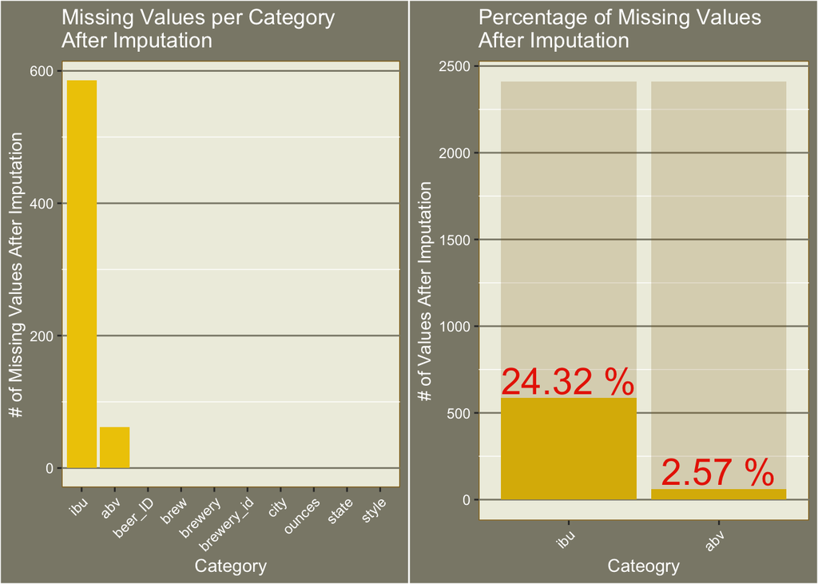

```r
#Now we repeat the process to extract the match based on category

t_beer_catz <- beer_catz

#t_beer_catz

t_beer_catz$category <- str_replace_all(as.character(t_beer_catz$category),"[\\s]{1}", "~~")

t_beer_catz$category <- str_replace_all(as.character(t_beer_catz$category),"~~~~", "~~")

t_beer_catz$category <- str_replace_all(as.character(t_beer_catz$category), "((~~)(\\(.+))", "")

#t_beer_catz

#t_beer_catz$category



#We will get the index of matches as before

dfMatchesCatInx <-which(as.character(t_beer_catz$category)%in%as.character(df_BeerStyles$beerStyle))

#dfMatchesCatInx

#t_beer_catz[dfMatchesCatInx,][,1]



#There are 3 matches but only one of the matches had data associated with it, Scottish Ale
#This filtering below returns 3 beers with this class, we will average means for calcs

dfRefMatchesCat <- rng_df_t %>% filter(category_id == 14)

rng_df_f <- rbind(rng_df_t[dfRefMatchesSubCat_inx,], dfRefMatchesCat)

#rng_df_f




#Now we will write to csv to load into our data set if desired

# write.csv(rng_df_f, file="[YOUR FILE PATH AND NAME HERE]")

# write.csv(rng_df_t, file="[YOUR FILE PATH AND NAME HERE]")

# Here are the beers from the full df with missing ibu values
ibu_blnks <- dfFull %>% filter(is.na(ibu))

#ibu_blnks


#Same with ABV for beers
abv_blnks <- dfFull %>% filter(is.na(abv))

#abv_blnks


#Make of copy of the style column strip white space and create special char for lookup

ibu_blnks <- mutate(ibu_blnks, t_style = ibu_blnks$style)

ibu_blnks$t_style <- str_replace_all(as.character(ibu_blnks$t_style),"[/]{1}", "")

ibu_blnks$t_style <- str_replace_all(as.character(ibu_blnks$t_style),"[\\s]{1}", "~~")

ibu_blnks$t_style <- str_replace_all(as.character(ibu_blnks$t_style),"~~~~", "~~")

ibu_blnks$t_style <- str_replace_all(as.character(ibu_blnks$t_style), "((~~)(\\(.+))", "")

# uncomment this to see all of them
#ibu_blnks



#This will return the indexes of the beers from the the ibu_blnks df where the special char text will be matched to our reference

dfRefMatchesSubCat <- which(as.character(ibu_blnks$t_style)%in%as.character(beerSubcats$beerSubcat))

#dfRefMatchesSubCat



#Here we extract the rows from the blanks df that have matches
df_to_impt <- ibu_blnks[dfRefMatchesSubCat,]

#df_to_impt


inxHolder = list()


for (i in 1:dim(df_to_impt)[1])
{
  inxHolder <- rbind(inxHolder, as.numeric(grep(df_to_impt$t_style[[i]], beerSubcats$beerSubcat)))
}



#inxHolder
df_to_impt <- cbind(df_to_impt, inxHolder)

#df_to_impt


df_to_impt <- mutate(df_to_impt, styIbu = mapply(function(x) rng_df_t[x,9], df_to_impt$inxHolder))

#df_to_impt

ibus_to_replace <- df_to_impt[[13]]

#ibus_to_replace

df_to_impt$ibu <- df_to_impt$styIbu

#df_to_impt

df_imputed_ibus <- df_to_impt

#df_imputed_ibus




#~~~~~~~~~~Imputation of the dfFull~~~~~~~~~~~~~~~

dfFull_imp <- dfFull

dfFull_inx_to_impt <- which(is.na(dfFull$ibu))

j <- as.numeric(c(1))

for (i in 1: length(dfFull_inx_to_impt))
{

  dfFull_imp[as.numeric(dfFull_inx_to_impt[[i]]),4] <- df_imputed_ibus[j,4]
  j <- j+1

}

ibu_miss_val <- dfFull %>% filter(is.na(ibu))

#df_imputed_ibus



notNaCols_imp <- colSums(!is.na(dfFull_imp), na.rm = TRUE) %>% tibble::enframe(name = NULL)

#notNaCols

isNaCols_imp <- colSums(is.na(dfFull_imp), na.rm = FALSE)%>% tibble::enframe(name = NULL)

#isNaCols

dfFull_vt_imp <- cbind(names(dfFull_imp),notNaCols_imp) #


dfFull_vt_imp <- cbind(dfFull_vt_imp, isNaCols_imp)

names(dfFull_vt_imp) <- c("column", "notNA", "isNA")





#First try to store the raw data rather than truncate, can always truncate later/after

#dfFull_vt <- dfFull_vt %>% mutate(percentNA = mapply(function(x,y) round(y/(x+y),4)*100,dfFull_vt$notNA, dfFull_vt$isNA))

dfFull_vt_imp <- dfFull_vt_imp %>% mutate(total = rowSums(dfFull_vt_imp[,2:3]))

dfFull_vt_imp <- dfFull_vt_imp %>% mutate(percentNA = mapply(function(x,y) y/(x+y),dfFull_vt_imp$notNA, dfFull_vt_imp$isNA))





#dfFull_vt_imp


naPlot1_imp <- dfFull_vt_imp %>%
  ggplot(aes(x=reorder(column, -isNA), y = isNA)) +
  geom_histogram(stat = "identity", fill ="gold2") +
  labs(x="Category", y="# of Missing Values After Imputation", title = "Missing Values per Category\nAfter Imputation") +
  #theme_minimal() +
  theme(axis.text=element_text(color = "white"),
        axis.text.x = element_text(angle=45, hjust = 1),
        legend.position =  "none",
        plot.background = element_rect("cornsilk4"),
        panel.background = element_rect(color="darkgoldenrod4", fill='ivory2'),
        panel.grid.major.y = element_line(color="cornsilk4"),
        panel.grid.major.x = element_blank(),#element_line("ivory2"),
        axis.title = element_text(color = "white"),
        plot.title = element_text(color = "white"),
        panel.grid.minor.x = element_line(color="white"))
#naPlot1

naPlot2_imp <- dfFull_vt_imp[c(3:4),] %>%
  ggplot(aes(x=reorder(column, -isNA), y = isNA)) +
  geom_histogram(stat = "identity", fill = 'gold2') +
  geom_text(data=dfFull_vt_imp[c(3:4),], label=paste(round((dfFull_vt_imp[c(3:4),]$percentNA)*100, 2), "%"),
            y = (dfFull_vt_imp[c(3:4),]$isNA)+100, size = 8, color="red") +
  geom_histogram(data=dfFull_vt_imp[3:4,], mapping = aes(x=column, y = total),
                 stat = "identity", alpha = 1/5, fill="darkgoldenrod4") +
  labs(x="Cateogry", y="# of Values After Imputation", title = "Percentage of Missing Values\nAfter Imputation") +
  #theme_minimal() +
  theme(axis.text=element_text(color = "white"),
        axis.text.x = element_text(angle=45, hjust = 1),
        legend.position =  "none",
        plot.background = element_rect("cornsilk4"),
        panel.background = element_rect(color="darkgoldenrod4", fill='ivory2'),
        panel.grid.major.x = element_blank(),#element_line("ivory2"),
        panel.grid.major.y = element_line(color="cornsilk4"),
        axis.title = element_text(color = "white"),
        plot.title = element_text(color = "white"),
        panel.grid.minor.x = element_line(color="white"))
#plot.margin = margin(l=-5))

#naPlot2

grid.arrange(naPlot1_imp,naPlot2_imp, nrow=1)
```

## 4. Compute the median alcohol content and international bitterness unit for each state. Plot a bar chart to compare.

```r
# let's use the original dataset for this, not with all the average values filled in
#dfFull
write.csv(dfFull, "FullBeerData.csv")

dfMedianABVAndIBUByState <- dfFull %>%
  group_by(state) %>%
  summarize(MeanABV = mean(abv,na.rm = TRUE), MeanIBU = mean(ibu, na.rm = TRUE)) %>% rename(state = state)

dfMedianABVAndIBUByState
```

```
## # A tibble: 51 x 3
##    state MeanABV MeanIBU
##    <fct>   <dbl>   <dbl>
##  1 " AK"  0.0556    40.9
##  2 " AL"  0.062     51.2
##  3 " AR"  0.052     39
##  4 " AZ"  0.0602    35.2
##  5 " CA"  0.0611    46.3
##  6 " CO"  0.0634    47.4
##  7 " CT"  0.0611    40.8
##  8 " DC"  0.0656    55.2
##  9 " DE"  0.055     52
## 10 " FL"  0.0599    46.8
## # … with 41 more rows
```

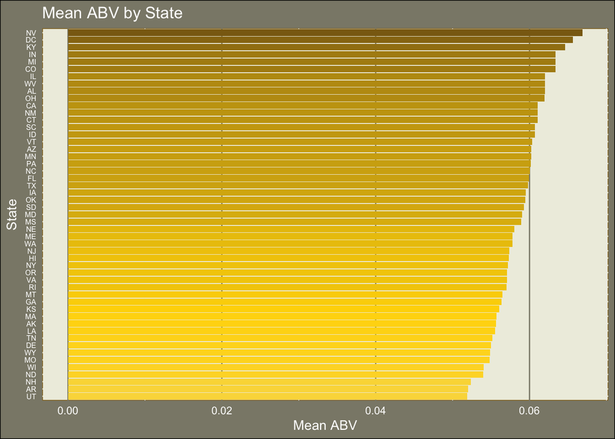

```r
# this looks interesting https://medium.com/@NickDoesData/visualizing-geographic-data-in-r-fb2e0f5b59c5
# the one "simple bar chart of state gdps" with a coordinate flip looks interesting
# TODO : this needs some color. Ideally different color for each state, but the color matches on each graph so they line up
dfMedianABVAndIBUByState %>%
ggplot()+
  geom_bar(mapping=aes(x=reorder(state, MeanABV), y=MeanABV, fill=MeanABV), stat = 'identity') +
  coord_flip() +
  #scale_y_continuous(expand = c(0,0), limits = c(0,2.75)) +
  ylab("Mean ABV") +
  xlab('State') +
  ggtitle('Mean ABV by State') +
  theme_minimal() +
  theme(axis.text=element_text(color = "white"),
        axis.text.y = element_text(size=6),
        legend.position =  "none",
        plot.background = element_rect("cornsilk4"),
        panel.background = element_rect(color="darkgoldenrod4", fill='ivory2'),
        panel.grid.major.y = element_line(color="ivory2"),
        panel.grid.major.x = element_line("cornsilk4"),
        axis.title = element_text(color = "white"),
        plot.title = element_text(color = "white")) +
  scale_fill_gradient2(low = "lightgoldenrod", mid = "gold", high = "goldenrod4", midpoint = 0.056)
```

```r
mean(dfMedianABVAndIBUByState$MeanABV)
```

```
## [1] 0.05869683
```

```r
min(dfMedianABVAndIBUByState$MeanABV)
```

```
## [1] 0.05188462
```

```r
max(dfMedianABVAndIBUByState$MeanABV)
```

```
## [1] 0.0669
```

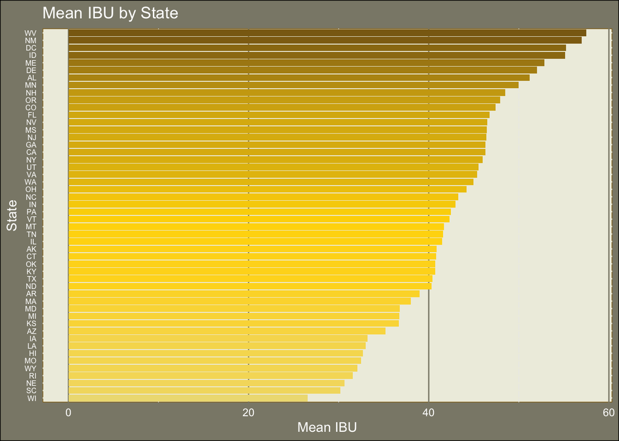

```r
# let's plot MeanIBU in same order as MeanABV so we can compare
#NEED to fix the label


dfMedianABVAndIBUByState %>% filter(!is.na(MeanIBU)) %>%
ggplot()+
  geom_bar(mapping=aes(x=reorder(state, MeanIBU), y=MeanIBU, fill = MeanIBU), stat = 'identity') +
  coord_flip() +
  #scale_y_continuous(expand = c(0,0), limits = c(0,2.75)) +
  ylab("Mean IBU") +
  xlab('State') +
  ggtitle('Mean IBU by State') +
  theme_minimal() +
  theme(axis.text=element_text(color = "white"),
        axis.text.y = element_text(size=6),
        legend.position =  "none",
        plot.background = element_rect("cornsilk4"),
        panel.background = element_rect(color="darkgoldenrod4", fill='ivory2'),
        panel.grid.major.y = element_line(color="ivory2"),
        panel.grid.major.x = element_line("cornsilk4"),
        axis.title = element_text(color = "white"),
        plot.title = element_text(color = "white")) +
  scale_fill_gradient2(low = "lightgoldenrod", mid = "gold", high = "goldenrod4", midpoint = 42)
```